# Lectures 10–11 Exercise — Trees, Bagging, Random Forests and Boosting

PubH 6010 Independent Study · Replicating Lombard et al. (2021): machine-learning models of arsenic in US private wells

Katie O’Brien

2026-11-15

# 1 Overview

Lectures 10 and 11 cover all of the tree-based methods: **classification trees** with cost-complexity pruning, **bagging**, **random forests** and **boosting**, plus **variable importance** and **partial dependence plots**. This week’s paper uses boosting and a random forest to build a national map of arsenic in private wells. It is a direct example of ML used for **exposure assessment** in a health study.

> Lombard MA, Scannell Bryan M, Jones DK, Bulka C, Bradley PM, Backer LC, Focazio MJ, Silverman DT, Toccalino P, Argos M, Gribble MO, Ayotte JD. Machine learning models of arsenic in private wells throughout the conterminous United States as a tool for exposure assessment in human health studies. *Environmental Science & Technology.* 2021;55(8):5012–5023. doi:[10.1021/acs.est.0c05239](https://doi.org/10.1021/acs.est.0c05239)

The data are a USGS data release: Lombard MA (2021), doi:[10.5066/P90RBJXS](https://doi.org/10.5066/P90RBJXS).

**Reading before you start.**

- Read the Introduction and Methods, Table 1 and the variable-importance figure (Figure 2).
- Skim the maps. The Discussion of how the maps should and should not be used in health studies is short and worth reading closely.

**The paper’s four models.**

| model | outcome | method | the paper’s tuned settings |
| --- | --- | --- | --- |
| BRT1 / BRT5 / BRT10 | arsenic > 1, > 5, > 10 µg/L (binary) | boosted regression trees (`gbm`) | BRT10: 4,500 trees, interaction depth 6, shrinkage 0.01, min. 10 obs. per node |
| RFC | ≤ 5, > 5 to ≤ 10, > 10 µg/L (3 classes) | random forest classification | 500 trees, m = 20 |

We focus on **> 10 µg/L**, the EPA maximum contaminant level (MCL) for public water systems. Private wells are not covered by the MCL. The paper selected tuning settings by 10-fold CV with the 1-SE rule, as in the slides, and evaluated on a held-out 30% of wells. The data file records which wells were in the paper’s training and test sets, so you can use **exactly the paper’s split**.

**Code: slides vs here.** As in previous weeks, we use tidymodels where the slides use `caret`. For the replication in Part A we call `gbm()` directly, because that is what the paper and slides 13–17 of Lecture 11 use.

| slides | here |
| --- | --- |
| `rpart(..., method = "class", cp = 0)`, `printcp()`, `plotcp()`, `prune()` | the same (Part B), plus `decision_tree(cost_complexity = tune()) \|> set_engine("rpart")` |
| `randomForest(..., mtry = 8)`, `train(method = "rf")` | `rand_forest(mtry = , trees = , min_n = 1) \|> set_engine("ranger")` |
| `gbm(..., distribution = "bernoulli")` | the same (Part A) |
| `train(method = "gbm", tuneGrid = expand.grid(...))` | `boost_tree(trees = tune(), tree_depth = tune(), learn_rate = tune()) \|> set_engine("xgboost")` |
| `varImpPlot()`, `summary(gbm_fit)`, `plot(gbm_fit, i = "x")` | the same for gbm; `importance = "permutation"` in ranger; `pdp_curve()` (starter code) |
| `trainControl("cv", number = 10)` | `vfold_cv(train, v = 5, strata = as10)`. We use 5 folds to keep the boosting grid under 5 minutes |

**Install once:** `install.packages(c("tidymodels", "gbm", "rpart.plot", "ranger", "xgboost", "probably"))`. `rpart` ships with R.

# 2 Data

`AsModelInput.csv`: 20,450 private wells sampled 1970–2013 across the conterminous US, × 93 columns. Well locations are not included. `Model_input_definitions.csv` defines every column, and `Model_input_sources.csv` gives the source datasets.

[output not shown]

Three things in the definitions file are wrong or inconsistent. The starter code accounts for them:

- `DMppt8110` is listed in inches. The values (65 to 3,098) are **millimetres** per year.
- The descriptions of `p_c` and `orgc_c` are swapped. `p_c` is phosphorus (mg/kg), and `orgc_c` is organic carbon (weight %).
- C3 is “≥ 10” but `bas10` is “> 10”, so wells at exactly 10 µg/L are C3 with `bas10 = 0`.

The starter code drops the 27 wells with a missing predictor and creates `as10`, a factor version of `bas10` with `"yes"` as the first level (yardstick treats the first level as the event).

Submit your knitted `.Rmd` with short written answers to the questions in **bold**.

# 3 Tasks

## 3.1 Part A — Replicate the boosted model for > 10 µg/L (L11 slides 4–7, 13–15)

1. Using the paper’s split (`spl10`), report the number of training and test wells and the proportion with arsenic > 10 µg/L in each.

```r
library(tidyverse)
library(tidymodels)
library(gbm)
library(rpart)
library(rpart.plot)
library(ranger)
library(xgboost)
library(probably)
tidymodels_prefer()

as_raw <- read_csv("AsModelInput.csv")
outcome_cols <- c("bas1", "bas5", "bas10", "As3Cat", "spl1", "spl5", "spl10", "spl3cat")
predictors   <- setdiff(names(as_raw), outcome_cols)          # 85 predictors

wells <- as_raw |>
  filter(if_all(all_of(predictors), \(x) !is.na(x))) |>      # drops 27 wells
  mutate(as10   = factor(if_else(bas10 == 1, "yes", "no"), levels = c("yes", "no")),
         As3Cat = factor(As3Cat))
train <- wells |> filter(spl10)
test  <- wells |> filter(!spl10)
f10   <- reformulate(predictors, response = "as10")

# ---- helper: the five Table 1 metrics at a probability cutoff ----------------
test_metrics <- function(truth, prob_yes, cut = 0.5) {
  cls <- factor(if_else(prob_yes > cut, "yes", "no"), levels = c("yes", "no"))
  tibble(accuracy    = accuracy_vec(truth, cls),
         sensitivity = sensitivity_vec(truth, cls),
         specificity = specificity_vec(truth, cls),
         auc         = roc_auc_vec(truth, prob_yes),
         kappa       = kap_vec(truth, cls))
}


train %>%
  count(bas10 == "1")
```

```
## # A tibble: 2 × 2
##   `bas10 == "1"`     n
##   <lgl>          <int>
## 1 FALSE          12759
## 2 TRUE            1544
```

```r
test %>%
  count(bas10 == "1")
```

```
## # A tibble: 2 × 2
##   `bas10 == "1"`     n
##   <lgl>          <int>
## 1 FALSE           5459
## 2 TRUE             661
```

There are 14,303 wells in the training dataset. 1,544 of these have arsenic levels above 10 ug/L. There are 6,120 wells in the testing dataset. 661 of these wells have arsenic levels above 10 ug/L.

2. Fit the paper’s BRT10 with `gbm()` (settings in the table above, `bag.fraction = 0.5`, `set.seed(1234)`). Compute test-set accuracy, sensitivity, specificity, AUC and kappa at the 0.5 cutoff, and the same on the training set, with `test_metrics()`. Put them next to the paper’s Table 1.

```r
# ---- Part A ------------------------------------------------------------------
set.seed(1234)
gbm10 <- gbm(reformulate(predictors, "bas10"), data = train,   # gbm wants a 0/1 outcome
             distribution = "bernoulli", n.trees = 4500, interaction.depth = 6,
             shrinkage = 0.01, n.minobsinnode = 10, bag.fraction = 0.5)   # ~2-4 min
p_gbm_test <- predict(gbm10, test, n.trees = 4500, type = "response")
metrics <- test_metrics(test$as10, p_gbm_test)

metrics_long <- metrics %>%
  pivot_longer(
    cols = everything(),
    names_to = "metric",
    values_to = " GBMmodel"
  )

table1 <- tibble(
  metric = c("accuracy", "sensitivity", "specificity", "auc", "kappa"),
  paper = c("91.2", "33.9", "98.2", "0.850", "0.413")
)


left_join(table1, metrics_long, by = "metric")
```

```
## # A tibble: 5 × 3
##   metric      paper ` GBMmodel`
##   <chr>       <chr>       <dbl>
## 1 accuracy    91.2        0.912
## 2 sensitivity 33.9        0.336
## 3 specificity 98.2        0.981
## 4 auc         0.850       0.856
## 5 kappa       0.413       0.409
```

3. Two baselines: the accuracy of predicting “no” for every well, and a main-effects logistic regression (`logistic_reg()`) on all 85 predictors.

```r
# baseline model for predicting no
p_baseline_no <- rep(0, nrow(test))
test_metrics(test$as10, p_baseline_no)
```

```
## # A tibble: 1 × 5
##   accuracy sensitivity specificity   auc kappa
##      <dbl>       <dbl>       <dbl> <dbl> <dbl>
## 1    0.892           0           1   0.5     0
```

```r
# logistic regression model
logit10 <- logistic_reg() |> fit(f10, data = train)
p_logit_test <- predict(logit10, test, type = "prob")$.pred_yes
test_metrics(test$as10, p_logit_test)
```

```
## # A tibble: 1 × 5
##   accuracy sensitivity specificity   auc kappa
##      <dbl>       <dbl>       <dbl> <dbl> <dbl>
## 1    0.901       0.129       0.995 0.795 0.194
```

> **Q1.** Do your numbers match Table 1? Give two reasons small differences could remain. Why is training performance so much better than test performance, and why is this a bigger concern for boosting than for a random forest (slide 7)? Compare the model’s 91% accuracy with the “always no” baseline. Which of the five metrics would you lead with in an abstract, and why? What does `interaction.depth = 6` mean in `gbm`?

The numbers do match table 1 for the most part, with some small differences. Small differences could remain because the models uses a stochastic process, which is random, and the samples chosen in the subsampling step may be different every time. Training performance is better than test performance because the model is using data it has seen before. This is a bigger concern for boosting than for random forest because, in boosting, decisions are made based on the previous tree, so the order the trees were created in is important. The accuracy of the “always no” model is 89%. I would lead with accuracy in the metric because it describes the ratio of correct predictions to total predictions, which would be helpful for this topic. In GBM, interaction.depth specifies the maximum number of splits to perform on each individual tree.

## 3.2 Part B — A single classification tree (L10 slides 25–37)

4. Grow the maximal tree with `rpart(..., cp = 0, xval = 10)` (slide 31). Use `plotcp()` and the `cptable` to find the α with the smallest CV error and the α chosen by the 1-SE rule.

```r
set.seed(1234)
tree_max <- rpart(f10, data = train, method = "class", parms = list(split = "gini"),
                  control = rpart.control(minsplit = 20, minbucket = 5, cp = 0, xval = 10))
printcp(tree_max)
```

```
##
## Classification tree:
## rpart(formula = f10, data = train, method = "class", parms = list(split = "gini"),
##     control = rpart.control(minsplit = 20, minbucket = 5, cp = 0,
##         xval = 10))
##
## Variables actually used in tree construction:
##  [1] as_c        be_c        BFI         bi_c        D3          De
##  [7] DMppt8110   DSe         inorgc_c    Kg          LP2         LP4
## [13] LP6         mo_c        na_10.1     na_13.1     na_8.1      na_9.6
## [19] ni_c        Oe          orgc_c      p_c         Percent_Ti  PRMS8110Re
## [25] Pzg2        Q           rt_carb     rt_clast_f  rt_clast_u  rt_plut_qtz
## [31] sb_c        se_c        Tmc         Tp          Tpc         Tpv
## [37] Txc         uc_12       uc_321      uc_322      uc_331      uc_620
## [43] uc_812      uc_970      Wgn
```

[output cut: 35 more lines]

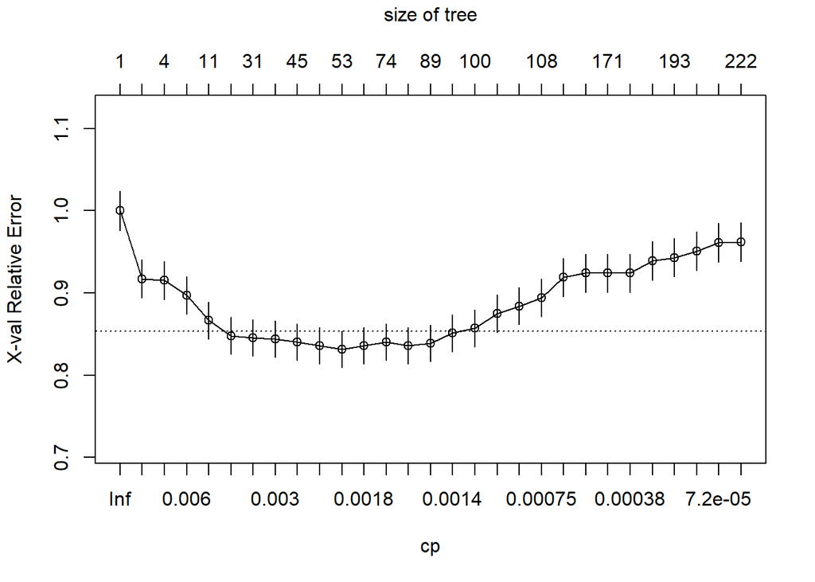

```r
plotcp(tree_max)
```

5. Tune `cost_complexity` with tidymodels on the 5 folds, with both `accuracy` and `roc_auc` as metrics. Plot both against α. Report the test metrics of the tree chosen by the 1-SE rule on accuracy and of the tree with the best CV AUC.

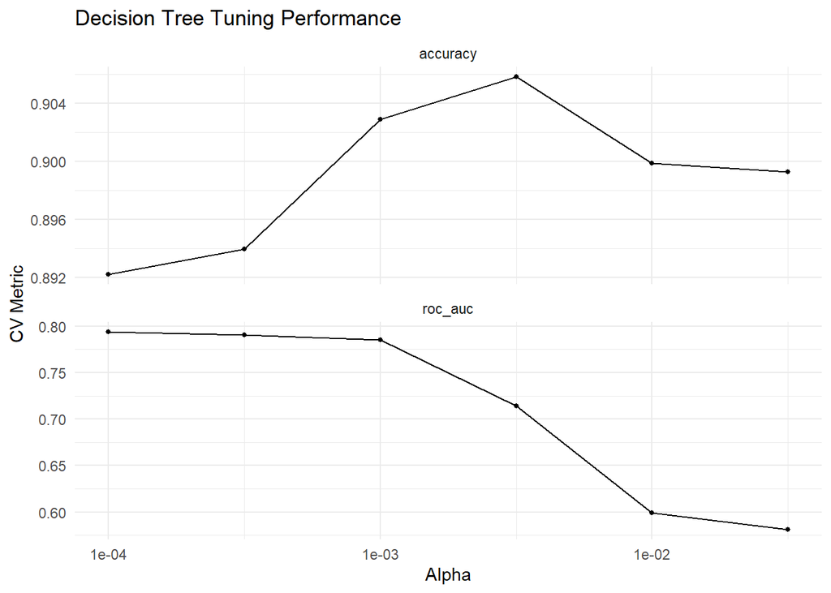

```r
set.seed(1234)
folds <- vfold_cv(train, v = 5, strata = as10)            # reuse these folds in Part D
cart_spec <- decision_tree(cost_complexity = tune(), min_n = 20) |>
  set_engine("rpart") |> set_mode("classification")
cart_res <- tune_grid(workflow(f10, cart_spec), resamples = folds,
                      grid = tibble(cost_complexity = 10^seq(-4, -1.5, by = 0.5)),
                      metrics = metric_set(accuracy, roc_auc))
# model chosen by 1 SE rule using accuracy
hp_1se_acc <- select_by_one_std_err(cart_res, desc(cost_complexity), metric = "accuracy")

# plotting accuracy and ROC against alpha
autoplot(cart_res) +
  scale_x_log10() +
  labs(
    x = "Alpha",
    y = "CV Metric",
    title = "Decision Tree Tuning Performance"
  ) +
  theme_minimal()
```

```r
hp_best_auc <- select_best(
  cart_res,
  metric = "roc_auc"
)

cart_wf <- workflow(f10, cart_spec)

# helper function for test metrics
get_model_test_metrics <- function(hp_selected, model_label) {
  final_wf <- finalize_workflow(cart_wf, hp_selected)
  fit_model <- fit(final_wf, data = train)

  # Predict test probabilities for the positive class ("yes")
  test_probs <- predict(fit_model, new_data = test, type = "prob")$.pred_yes

  # Calculate test metrics using your custom helper function
  test_metrics(truth = test$as10, prob_yes = test_probs, cut = 0.5) %>%
    mutate(model = model_label, .before = 1)
}

# metrics for models chosen by 1 SE accuracy and CV AUC
results_1se_acc  <- get_model_test_metrics(hp_1se_acc, "1-SE Rule (Accuracy)")
results_best_auc <- get_model_test_metrics(hp_best_auc, "Best CV AUC")

combined_test_metrics <- bind_rows(results_1se_acc, results_best_auc)

print(combined_test_metrics)
```

```
## # A tibble: 2 × 6
##   model                accuracy sensitivity specificity   auc kappa
##   <chr>                   <dbl>       <dbl>       <dbl> <dbl> <dbl>
## 1 1-SE Rule (Accuracy)    0.905       0.212       0.989 0.723 0.290
## 2 Best CV AUC             0.889       0.393       0.949 0.791 0.374
```

6. Prune to a small tree (`cp = 0.0065`, 3 splits) and draw it with `rpart.plot()`. Then grow the same small tree on three bootstrap resamples of the training wells (`slice_sample(train, prop = 1, replace = TRUE)`) and record the first few splits of each.

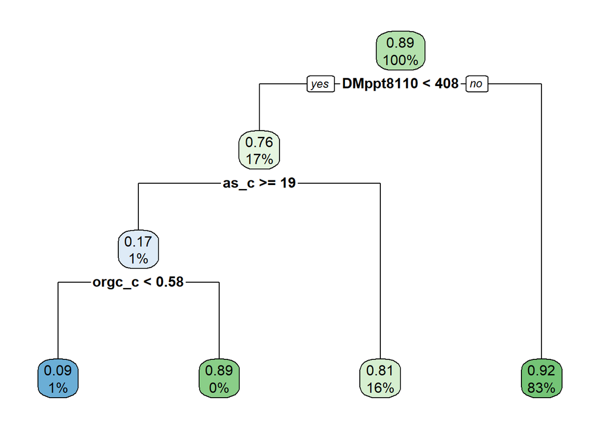

```r
# prune to a small tree
tree_small <- rpart::prune(tree_max, cp = 0.0065)   # rpart::, because another package also has a prune()
rpart.plot(tree_small, extra = 107)
```

```r
tree_formula <- formula(tree_max)
tree_control <- tree_max$control

# Set seed for reproducibility across bootstrap samples
set.seed(123)

# bootstrap samples
for (i in 1:3) {

  # resample with replacement
  boot_train <- slice_sample(train, prop = 1, replace = TRUE)

  # fit tree and prune
  boot_tree_max <- rpart(tree_formula, data = boot_train, control = tree_control)
  boot_tree_small <- rpart::prune(boot_tree_max, cp = 0.0065)

  # show first few splits
  print(boot_tree_small)
}
```

```
## n= 14303
##
## node), split, n, loss, yval, (yprob)
##       * denotes terminal node
##
##  1) root 14303 1562 no (0.10920786 0.89079214)
##    2) DMppt8110< 399.983 2417  592 no (0.24493173 0.75506827)
##      4) as_c>=18.7659 180   32 yes (0.82222222 0.17777778)
##        8) orgc_c< 0.660784 161   16 yes (0.90062112 0.09937888) *
##        9) orgc_c>=0.660784 19    3 no (0.15789474 0.84210526) *
##      5) as_c< 18.7659 2237  444 no (0.19848011 0.80151989) *
##    3) DMppt8110>=399.983 11886  970 no (0.08160862 0.91839138)
##      6) na_8.1>=0.5 1995  335 no (0.16791980 0.83208020) *
##      7) na_8.1< 0.5 9891  635 no (0.06419978 0.93580022)
##       14) uc_331>=0.5 357   89 no (0.24929972 0.75070028)
##         28) p_c< 181.302 73   20 yes (0.72602740 0.27397260) *
##         29) p_c>=181.302 284   36 no (0.12676056 0.87323944) *
##       15) uc_331< 0.5 9534  546 no (0.05726872 0.94273128) *
## n= 14303
##
## node), split, n, loss, yval, (yprob)
##       * denotes terminal node
##
##  1) root 14303 1557 no (0.10885828 0.89114172)
##    2) DMppt8110< 417.283 2590  629 no (0.24285714 0.75714286)
##      4) as_c>=18.6357 195   31 yes (0.84102564 0.15897436)
##        8) orgc_c< 0.584837 176   16 yes (0.90909091 0.09090909) *
##        9) orgc_c>=0.584837 19    4 no (0.21052632 0.78947368) *
##      5) as_c< 18.6357 2395  465 no (0.19415449 0.80584551) *
##    3) DMppt8110>=417.283 11713  928 no (0.07922821 0.92077179)
##      6) na_8.1>=0.5 2044  356 no (0.17416830 0.82583170)
##       12) sb_c< 0.1997715 583  178 no (0.30531732 0.69468268)
##         24) bi_c>=0.0983075 363  152 no (0.41873278 0.58126722)
##           48) BFI>=55.5 108   33 yes (0.69444444 0.30555556)
##             96) DMppt8110< 1316.1 83   14 yes (0.83132530 0.16867470) *
##             97) DMppt8110>=1316.1 25    6 no (0.24000000 0.76000000) *
##           49) BFI< 55.5 255   77 no (0.30196078 0.69803922)
##             98) DMppt8110< 1215.415 44   13 yes (0.70454545 0.29545455) *
##             99) DMppt8110>=1215.415 211   46 no (0.21800948 0.78199052) *
##         25) bi_c< 0.0983075 220   26 no (0.11818182 0.88181818) *
##       13) sb_c>=0.1997715 1461  178 no (0.12183436 0.87816564) *
##      7) na_8.1< 0.5 9669  572 no (0.05915813 0.94084187)
##       14) uc_331>=0.5 330   75 no (0.22727273 0.77272727)
##         28) BFI< 15.5 139   68 no (0.48920863 0.51079137)
##           56) p_c< 205.421 70   17 yes (0.75714286 0.24285714) *
##           57) p_c>=205.421 69   15 no (0.21739130 0.78260870) *
##         29) BFI>=15.5 191    7 no (0.03664921 0.96335079) *
##       15) uc_331< 0.5 9339  497 no (0.05321769 0.94678231) *
## n= 14303
##
## node), split, n, loss, yval, (yprob)
##       * denotes terminal node
##
## 1) root 14303 1555 no (0.10871845 0.89128155)
##   2) as_c>=18.77935 383  189 no (0.49347258 0.50652742)
##     4) Q>=0.5 192   22 yes (0.88541667 0.11458333) *
##     5) Q< 0.5 191   19 no (0.09947644 0.90052356) *
##   3) as_c< 18.77935 13920 1366 no (0.09813218 0.90186782) *
```

```r
cor(wells$as_c, wells$sb_c)
```

```
## [1] 0.5153705
```

> **Q2.** Describe the small tree in two sentences a state health department could use. Why do accuracy and AUC choose such different trees (think about the 89% baseline and slide 30)? How does the best single tree compare with the boosted model and with logistic regression? What did the bootstrap resamples show, and how does it connect to the motivation for bagging (slides 37–40)? Hint: compute the correlation between `as_c` and `sb_c`.

## 3.3 Part C — Bagging and random forests (L10 slides 38–53)

7. With `rf_fit()` (starter code), fit bagging (m = 85) and a random forest (m = 9 ≈ √85) for B ∈ {10, 25, 50, 100, 250, 500, 1000}. Plot the OOB error against B for both (slide 44).

```r
# starter code
# min_n = 1 grows full trees, as randomForest() does (slides 41, 52)
rf_fit <- function(mtry, trees = 500, data = train, formula = f10, ...) {
  rand_forest(mtry = mtry, trees = trees, min_n = 1) |>
    set_engine("ranger", seed = 1234, ...) |>
    set_mode("classification") |>
    fit(formula, data = data)
}
rf20 <- rf_fit(20)
extract_fit_engine(rf20)$prediction.error                 # OOB Brier score
```

```
## [1] 0.06621888
```

```r
oob_prob <- extract_fit_engine(rf20)$predictions[, "yes"] # OOB probability for every training well
roc_auc_vec(train$as10, oob_prob)                         # OOB AUC
```

```
## [1] 0.8642034
```

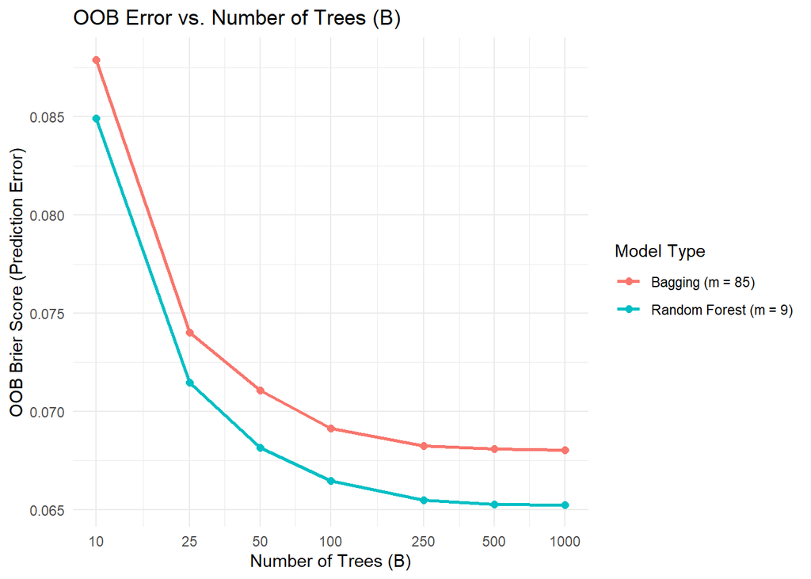

```r
# 3-class: rf_fit(20, data = train3, formula = reformulate(predictors, "As3Cat"))
#   with train3 <- wells |> filter(!is.na(As3Cat), spl3cat)



# B grid
B_grid <- c(10, 25, 50, 100, 250, 500, 1000)

# function to extract OOB error
get_oob_error <- function(mtry, trees) {
  fit_obj <- rf_fit(mtry = mtry, trees = trees)
  extract_fit_engine(fit_obj)$prediction.error
}

# grid search across B for bagging (m = 85) and random forest (m = 9)
q7_results <- expand.grid(
  trees = B_grid,
  model = c("Bagging (m = 85)", "Random Forest (m = 9)")
) %>%
  mutate(
    mtry = if_else(model == "Bagging (m = 85)", 85, 9),
    oob_error = map2_dbl(mtry, trees, get_oob_error)
  )

# plotting OOB error aginast B values
ggplot(q7_results, aes(x = trees, y = oob_error, color = model, group = model)) +
  geom_line(size = 1) +
  geom_point(size = 2) +
  scale_x_log10(breaks = B_grid) +
  labs(
    x = "Number of Trees (B)",
    y = "OOB Brier Score (Prediction Error)",
    title = "OOB Error vs. Number of Trees (B)",
    color = "Model Type"
  ) +
  theme_minimal()
```

8. With B = 500, fit m ∈ {1, 3, 6, 9, 15, 20, 30, 45, 60, 85}. Tabulate the OOB Brier score and OOB AUC against m. Report the test metrics for bagging, m = 9 and the paper’s m = 20.

```r
# M grid
m_grid <- c(1, 3, 6, 9, 15, 20, 30, 45, 60, 85)

# function to get OOB error
get_oob_metrics <- function(mtry) {
  fit_obj <- rf_fit(mtry = mtry, trees = 500)
  engine <- extract_fit_engine(fit_obj)

  brier <- engine$prediction.error
  oob_prob <- engine$predictions[, "yes"]
  auc <- roc_auc_vec(train$as10, oob_prob)

  tibble(m = mtry, oob_brier = brier, oob_auc = auc)
}

#calculate OOB brier and OOB AUC
q8_oob_table <- map_dfr(m_grid, get_oob_metrics)
print("OOB Brier and OOB AUC Table:")
```

```
## [1] "OOB Brier and OOB AUC Table:"
```

```r
print(q8_oob_table)
```

```
## # A tibble: 10 × 3
##        m oob_brier oob_auc
##    <dbl>     <dbl>   <dbl>
##  1     1    0.0874   0.815
##  2     3    0.0717   0.866
##  3     6    0.0654   0.871
##  4     9    0.0653   0.869
##  5    15    0.0661   0.864
##  6    20    0.0662   0.864
##  7    30    0.0669   0.859
##  8    45    0.0672   0.858
##  9    60    0.0675   0.857
## 10    85    0.0681   0.857
```

```r
# helper to evaluate performance
eval_rf_test <- function(mtry, label) {
  fit_obj <- rf_fit(mtry = mtry, trees = 500)

  # predict test probabilities for positive class "yes"
  test_prob <- predict(fit_obj, new_data = test, type = "prob")$.pred_yes

  test_metrics(truth = test$as10, prob_yes = test_prob, cut = 0.5) %>%
    mutate(model = label, m = mtry, .before = 1)
}

# test metrics for Bagging (m = 85), m = 9, and m = 20
test_bagging <- eval_rf_test(85, "Bagging (m = 85)")
test_m9      <- eval_rf_test(9,  "Random Forest (m = 9)")
test_m20     <- eval_rf_test(20, "Paper's RF (m = 20)")

q8_test_metrics <- bind_rows(test_bagging, test_m9, test_m20)
print(q8_test_metrics)
```

```
## # A tibble: 3 × 7
##   model                     m accuracy sensitivity specificity   auc kappa
##   <chr>                 <dbl>    <dbl>       <dbl>       <dbl> <dbl> <dbl>
## 1 Bagging (m = 85)         85    0.909       0.396       0.971 0.850 0.436
## 2 Random Forest (m = 9)     9    0.914       0.349       0.982 0.858 0.427
## 3 Paper's RF (m = 20)      20    0.912       0.392       0.975 0.856 0.444
```

9. Replicate the paper’s 3-class RFC on its split (`spl3cat`, m = 20, 500 trees). Report accuracy on the training data, OOB accuracy, test accuracy and test kappa, and the accuracy of always predicting C1. Make the test confusion matrix and compute the precision and recall of each class.

```r
#  3-class training and testing datasets
train3 <- wells %>% filter(!is.na(As3Cat), spl3cat)
test3  <- wells %>% filter(!is.na(As3Cat), !spl3cat)

# extract predictor variable names from f10
predictors <- all.vars(f10[[3]])
f3cat <- reformulate(predictors, "As3Cat")

# 3-class Random Forest model
rf3_fit <- rf_fit(mtry = 20, trees = 500, data = train3, formula = f3cat)
rf3_engine <- extract_fit_engine(rf3_fit)

# training accuracy and kappa
train3_preds <- predict(rf3_fit, new_data = train3)$.pred_class
train_acc <- accuracy_vec(train3$As3Cat, train3_preds)

# OOB accuracy
oob_acc <- 1 - rf3_engine$prediction.error

# test accuracy and kappa
test3_preds <- predict(rf3_fit, new_data = test3)$.pred_class
test_acc   <- accuracy_vec(test3$As3Cat, test3_preds)
test_kappa <- kap_vec(test3$As3Cat, test3_preds)

# baseline accuracy
baseline_acc <- mean(test3$As3Cat == "C1")

# test confusion matrix
test3_df <- tibble(
  truth = test3$As3Cat,
  estimate = test3_preds
)

conf_mat_3class <- conf_mat(test3_df, truth = truth, estimate = estimate)
print(conf_mat_3class)
```

```
##           Truth
## Prediction   C1   C2   C3
##         C1 4508  371  333
##         C2   64   61   57
##         C3  121   66  323
```

```r
# per-class precision and recall
cm <- conf_mat_3class$table
precision <- diag(cm) / rowSums(cm)
recall <- diag(cm) / colSums(cm)

per_class_metrics <- tibble(
  class = colnames(cm),
  precision = precision,
  recall = recall
)

print(per_class_metrics)
```

```
## # A tibble: 3 × 3
##   class precision recall
##   <chr>     <dbl>  <dbl>
## 1 C1        0.865  0.961
## 2 C2        0.335  0.122
## 3 C3        0.633  0.453
```

> **Q3.** How many trees are enough, and can too many trees hurt here (slide 51)? Which m is best, and why does bagging do worse than a random forest on these predictors (slide 50)? The paper reports 100% training accuracy for the RFC. Is that evidence of overfitting, and which of your numbers is the honest estimate of performance on new wells? Why is C2 (5–10 µg/L) so hard to predict, and why does that matter for a health study? Finally, compare your per-class precision and recall with the paper’s “user’s” and “producer’s” accuracy (look up the definitions). What do you notice?

About 250 trees are enough based on the OOB error. There is no risk of overfitting by using more trees. m = 9 is best based on the OOB error. Bagging does worse than random forest on these predictors because the predictors are highly correlated. 100% training accuracy for the RFC is evidence of overfitting. The honest estimate of performance on new wells is 83% accuracy. C2 is hard to predict because there are fewer wells that fit into this category in the training dataset. This matters for a health study because accurately predicting contaminated wells is important for employing appropriate interventions.

## 3.4 Part D — Tuning boosted trees with tidymodels (L11 slides 7, 18–21)

10. Tune `boost_tree()` with the xgboost engine (`min_n = 10`, `sample_size = 0.5`) over trees ∈ {250, 500, 1000, 2000, 3000} × tree_depth ∈ {1, 3, 6} × learn_rate ∈ {0.01, 0.1}, using CV AUC. Plot CV AUC against trees, coloured by depth and faceted by learning rate.

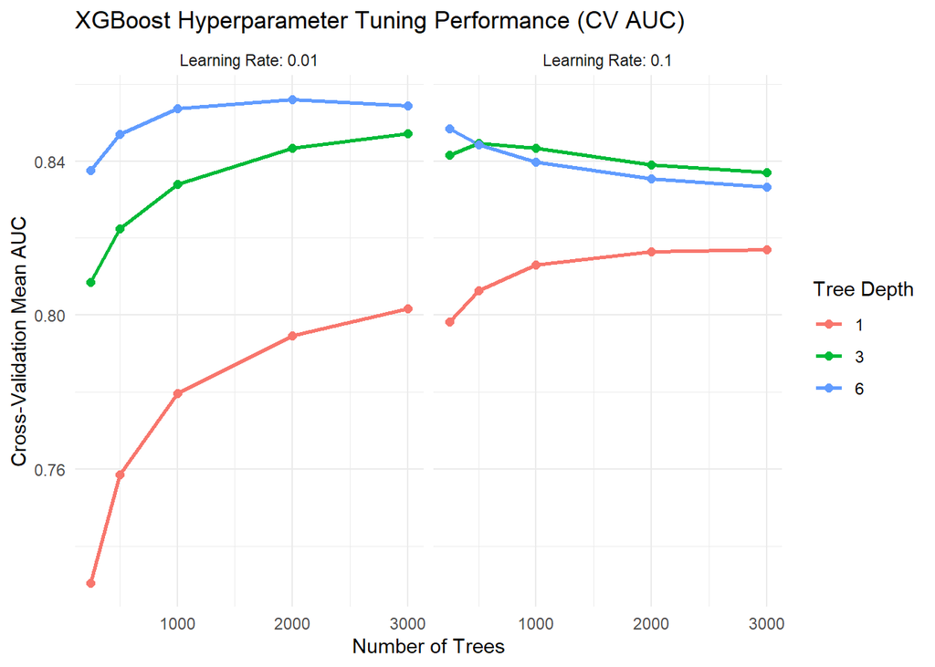

```r
xgb_spec <- boost_tree(trees = tune(), tree_depth = tune(), learn_rate = tune(),
                       min_n = 10, sample_size = 0.5) |>
  set_engine("xgboost") |> set_mode("classification")
xgb_grid <- expand_grid(trees = c(250, 500, 1000, 2000, 3000),
                        tree_depth = c(1, 3, 6), learn_rate = c(0.01, 0.1))
xgb_res <- tune_grid(workflow(f10, xgb_spec), resamples = folds, grid = xgb_grid,
                     metrics = metric_set(roc_auc, accuracy))     # ~2-5 min

# metrics
xgb_auc_df <- collect_metrics(xgb_res) |>
  filter(.metric == "roc_auc") |>
  mutate(
    tree_depth = factor(tree_depth),
    learn_rate_label = paste("Learning Rate:", learn_rate)
  )

# plot CV AUC against trees, colored by depth and faceted by learning
ggplot(xgb_auc_df, aes(x = trees, y = mean, color = tree_depth, group = tree_depth)) +
  geom_line(linewidth = 1) +
  geom_point(size = 2) +
  facet_wrap(~ learn_rate_label) +
  labs(
    x = "Number of Trees",
    y = "Cross-Validation Mean AUC",
    color = "Tree Depth",
    title = "XGBoost Hyperparameter Tuning Performance (CV AUC)"
  ) +
  theme_minimal()
```

11. Finalise the best setting with `last_fit()` on the paper’s split. Build one table of test metrics for: logistic regression, the best CART, bagging, random forest (m = 20), the paper’s gbm, and your tuned xgboost.

```r
xgb_final <- finalize_workflow(workflow(f10, xgb_spec), select_best(xgb_res, metric = "roc_auc")) |>
  last_fit(split = make_splits(train, test))
p_xgb_test <- collect_predictions(xgb_final)$.pred_yes

# comparison table
p_rf20  <- predict(rf20, test, type = "prob")$.pred_yes
p_gbm   <- predict(gbm10, test, n.trees=4500, type = "response")
p_bag <- predict(rf_fit(85), test, type = "prob")$.pred_yes

cart_final_wf <- finalize_workflow(cart_wf, hp_1se_acc)
cart_final_fit <- fit(cart_final_wf, data = train)
p_cart <- predict(cart_final_fit, test, type = "prob")$.pred_yes



model_probs <- list(
  "Logistic Regression"  = p_logit_test,
  "Best CART (1-SE)"     = p_cart,
  "Bagging (m = 85)"     = p_bag,
  "Random Forest (m=20)" = p_rf20,
  "Paper's GBM"          = p_gbm,
  "Tuned XGBoost"        = p_xgb_test
)

all_test_metrics <- imap_dfr(model_probs, function(probs, model_name) {
  test_metrics(truth = test$as10, prob_yes = probs, cut = 0.5) %>%
    mutate(model = model_name, .before = 1)
})

print(all_test_metrics)
```

```
## # A tibble: 6 × 6
##   model                accuracy sensitivity specificity   auc kappa
##   <chr>                   <dbl>       <dbl>       <dbl> <dbl> <dbl>
## 1 Logistic Regression     0.901       0.129       0.995 0.795 0.194
## 2 Best CART (1-SE)        0.905       0.212       0.989 0.723 0.290
## 3 Bagging (m = 85)        0.909       0.396       0.971 0.850 0.436
## 4 Random Forest (m=20)    0.912       0.392       0.975 0.856 0.444
## 5 Paper's GBM             0.912       0.336       0.981 0.856 0.409
## 6 Tuned XGBoost           0.915       0.340       0.985 0.854 0.426
```

> **Q4.** What happens to CV AUC as B grows at ν = 0.1 vs ν = 0.01, and why? What do depth-1 trees (stumps) assume, and what does their gap from depth 6 tell you about interactions in arsenic geochemistry? Is xgboost’s `tree_depth = 6` the same as gbm’s `interaction.depth = 6`? In your final table, which differences are large and which are within noise? (A rough SE for a test AUC here is 0.008.)

At v = 0.01, CV AUC increases as tree depth increases. At 0.1, CV AUC increases from a tree depth of 1 vs tree depths of 3 vs 6, but AUC is relatively the same at tree depths of 3 vs 6. This is because at a slower learning rate, the model is more likely to not miss the minimum for the loss function. Depth-1 trees assume that there are no interactions between features. Their gap from depth-6 trees implies that there are interactions in arsenic geochemistry. Tree_depth in xgboost is not quite same thing as interaction.depth in gbm, but they are related. In the final table, there are large differences between sensitivity and kappa. There are also differences in AUC. In AUC, the differences between bagging, random forest, the paper’s GBM, and the tuned xgboost are all within noise (because they are within 1 SE of each other), but the differences bewteen logistic regression and best CART are large differences.

## 3.5 Part E — Interpretation and use in a health study (L11 slides 8–10)

12. Make one table of variable-importance ranks for gbm relative influence, RF impurity importance and RF permutation importance (m = 20). Compare the total gbm influence of the 17 continuous and the 68 binary predictors.

```r
summary(gbm10, plotit = FALSE)                                    # relative influence
```

```
##                     var      rel.inf
## DMppt8110     DMppt8110 12.286793861
## as_c               as_c  6.464245705
## p_c                 p_c  5.954527646
## se_c               se_c  5.265059937
## sb_c               sb_c  5.219320391
## BFI                 BFI  5.128324854
## LP6                 LP6  4.527891586
## be_c               be_c  4.252351772
## orgc_c           orgc_c  4.228647427
## LP4                 LP4  4.114282667
## PRMS8110Re   PRMS8110Re  4.065368931
## mo_c               mo_c  3.940714593
## inorgc_c       inorgc_c  3.860542943
## LP2                 LP2  3.597649789
## ni_c               ni_c  3.311775151
## bi_c               bi_c  3.217869461
## Percent_Ti   Percent_Ti  3.090546321
## na_8.1           na_8.1  1.967206548
## Q                     Q  1.421191255
## Tpc                 Tpc  1.334376542
## Tpv                 Tpv  1.064053434
## Se                   Se  0.917267813
## DSe                 DSe  0.877165857
## uc_331           uc_331  0.721319549
## uc_811           uc_811  0.696041264
## Tp                   Tp  0.602601565
## na_10.1         na_10.1  0.577027124
## Pzg2               Pzg2  0.477982674
## uc_431           uc_431  0.410345589
## rt_carb         rt_carb  0.396360512
## De                   De  0.351099846
## uc_12             uc_12  0.333600938
## S2                   S2  0.326273869
## Tmc                 Tmc  0.292118251
## na_13.1         na_13.1  0.287040581
## rt_clast_u   rt_clast_u  0.274298192
## Pzg1               Pzg1  0.269639526
## Wgn                 Wgn  0.254151475
## uK3b               uK3b  0.228788713
```

[output cut: 31 more lines]

```
## na_9.3           na_9.3  0.016326700
## uK3                 uK3  0.015490170
## uc_822           uc_822  0.012619289
## uPz                 uPz  0.007993615
## Tr                   Tr  0.004914977
## Txc                 Txc  0.004532021
## uK2                 uK2  0.002146362
## uc_221           uc_221  0.001680594
## uc_312           uc_312  0.000000000
## uc_620           uc_620  0.000000000
## uc_940           uc_940  0.000000000
## uc_960           uc_960  0.000000000
## O2                   O2  0.000000000
## Te2                 Te2  0.000000000
## uK4                 uK4  0.000000000
```

```r
rf_perm <- rf_fit(20, importance = "permutation")
extract_fit_engine(rf_perm)$variable.importance
```

```
##           BFI     DMppt8110    PRMS8110Re           LP2           LP4
##  1.250390e-02  3.193781e-02  5.847305e-03  1.399451e-03  2.487693e-03
##           LP6    Percent_Ti          as_c          be_c          bi_c
##  5.240031e-03  5.796322e-03  1.390631e-02  1.154279e-02  1.124845e-02
##      inorgc_c          mo_c          ni_c        orgc_c           p_c
##  1.147666e-02  1.351029e-02  1.198493e-02  1.056643e-02  2.073302e-02
##          sb_c          se_c         uc_12        uc_221        uc_312
##  1.604000e-02  1.482355e-02  4.200738e-03 -4.416711e-05 -3.182524e-05
##        uc_321        uc_322        uc_331        uc_421        uc_422
##  2.019525e-04 -1.954754e-05  2.163086e-03  3.147922e-04  2.933006e-04
##        uc_431        uc_451        uc_620        uc_811        uc_812
##  1.719729e-03  1.575512e-04  2.177430e-04  1.530272e-03  3.382330e-05
##        uc_821        uc_822        uc_910        uc_920        uc_940
##  1.655562e-04  2.834202e-05  1.335067e-04  1.834403e-04  1.756430e-05
##        uc_960        uc_970        uc_999       rt_carb    rt_clast_c
## -2.587567e-05 -4.484812e-05  4.677562e-05  1.020186e-03  9.374102e-04
##    rt_clast_f    rt_clast_u       rt_meta   rt_plut_qtz            D3
##  6.280443e-04  1.228382e-03  5.094165e-04  6.436877e-04  2.503233e-04
##            De           DSe            Kg            O2            Oe
##  7.023960e-05  3.325645e-03  3.641852e-05  5.099758e-06  9.942336e-05
##           PP4          Pzg1          Pzg2             Q            Qv
##  6.558711e-06  7.858609e-05  5.171383e-04  6.011829e-03  2.129016e-04
##            S2            Se           Te2            Tm           Toc
##  2.448237e-04  1.142763e-03  9.127770e-06  1.379868e-04  6.978384e-05
##           Tmc            Tp           Tpc           Tpv            Tr
##  5.616546e-04  2.145659e-04  2.302397e-03  6.998802e-04 -6.392436e-05
##           Txc           uK2           uK3          uK3b           uK4
## -4.110217e-05 -9.035897e-06  9.175337e-05 -1.677441e-05 -8.826792e-06
##           uPz           Wgn       na_10.1       na_11.1       na_12.1
##  3.961849e-05  7.129960e-05  3.709181e-03  3.764290e-04  1.089799e-05
##       na_13.1        na_6.2        na_7.1        na_8.1        na_8.2
##  1.190984e-03  5.855413e-04  3.470915e-04  1.427946e-02  7.885431e-04
##        na_9.2        na_9.3        na_9.4        na_9.5        na_9.6
##  2.358681e-04  1.209483e-04  8.467293e-04  1.350760e-04  9.108286e-05
```

```r
# GBM relative influence
gbm_imp <- summary(gbm10, plotit = FALSE) %>%
  as_tibble() %>%
  rename(variable = var, gbm_rel_inf = rel.inf)

# RF impurity importance
rf_imp_fit <- rf_fit(20, importance = "impurity")
rf_impurity_vec <- extract_fit_engine(rf_imp_fit)$variable.importance

rf_impurity_df <- tibble(
  variable = names(rf_impurity_vec),
  rf_impurity = as.numeric(rf_impurity_vec)
)

# RF permutation importance
rf_perm_fit <- rf_fit(20, importance = "permutation")
rf_perm_vec <- extract_fit_engine(rf_perm_fit)$variable.importance

rf_perm_df <- tibble(
  variable = names(rf_perm_vec),
  rf_permutation = as.numeric(rf_perm_vec)
)

# talbe
var_importance_ranks <- gbm_imp %>%
  full_join(rf_impurity_df, by = "variable") %>%
  full_join(rf_perm_df, by = "variable") %>%
  mutate(
    rank_gbm_rel_inf = min_rank(desc(gbm_rel_inf)),
    rank_rf_impurity = min_rank(desc(rf_impurity)),
    rank_rf_perm     = min_rank(desc(rf_permutation))
  ) %>%
  select(variable, rank_gbm_rel_inf, rank_rf_impurity, rank_rf_perm) %>%
  arrange(rank_gbm_rel_inf)

print(var_importance_ranks, n = 20)
```

```
## # A tibble: 85 × 4
##    variable   rank_gbm_rel_inf rank_rf_impurity rank_rf_perm
##    <chr>                 <int>            <int>        <int>
##  1 DMppt8110                 1                1            1
##  2 as_c                      2                7            6
##  3 p_c                       3                5            2
##  4 se_c                      4               15            4
##  5 sb_c                      5                6            3
##  6 BFI                       6                8            8
##  7 LP6                       7                2           17
##  8 be_c                      8               13           10
##  9 orgc_c                    9               10           13
## 10 LP4                      10                4           21
## 11 PRMS8110Re               11                9           15
## 12 mo_c                     12               14            7
## 13 inorgc_c                 13               12           11
## 14 LP2                      14                3           26
## 15 ni_c                     15               11            9
## 16 bi_c                     16               16           12
## 17 Percent_Ti               17               17           16
## 18 na_8.1                   18               18            5
## 19 Q                        19               20           14
## 20 Tpc                      20               19           22
## # ℹ 65 more rows
```

```r
# compare total GBM influence
continuous_vars <- train %>%
  select(all_of(gbm_imp$variable)) %>%
  map_lgl(~ is.numeric(.x) && length(unique(.x)) > 2)

var_types <- tibble(
  variable = names(continuous_vars),
  type = if_else(continuous_vars, "Continuous", "Binary")
)

# aggregate relative influence by predictor type
gbm_type_comparison <- gbm_imp %>%
  inner_join(var_types, by = "variable") %>%
  group_by(type) %>%
  summarise(
    num_predictors = n(),
    total_rel_influence = sum(gbm_rel_inf),
    pct_total_influence = (sum(gbm_rel_inf) / sum(gbm_imp$gbm_rel_inf)) * 100,
    mean_influence_per_var = mean(gbm_rel_inf),
    .groups = "drop"
  )

print(gbm_type_comparison)
```

```
## # A tibble: 2 × 5
##   type       num_predictors total_rel_influence pct_total_influence
##   <chr>               <int>               <dbl>               <dbl>
## 1 Binary                 68                17.5                17.5
## 2 Continuous             17                82.5                82.5
## # ℹ 1 more variable: mean_influence_per_var <dbl>
```

13. Draw partial dependence plots for precipitation (`DMppt8110`) from gbm and from the random forest with `pdp_curve()`, on one plot. Overlay the raw proportion of wells > 10 µg/L by precipitation decile.

```r
# partial dependence: average prediction when every well is set to each grid value (L11 slide 9)
pdp_curve <- function(pred_fun, data, var,
                      grid = quantile(data[[var]], seq(0.02, 0.98, length.out = 20))) {
  map_dfr(grid, \(v) tibble(value = v, yhat = mean(pred_fun(mutate(data, !!var := v)))))
}
set.seed(1)
pdp_sample <- slice_sample(train, n = 2000)          # 2,000 wells is plenty and much faster
pdp_curve(\(nd) predict(gbm10, nd, n.trees = 4500, type = "response"), pdp_sample, "DMppt8110")
```

```
## # A tibble: 20 × 2
##    value   yhat
##    <dbl>  <dbl>
##  1  207. 0.245
##  2  297. 0.184
##  3  360. 0.174
##  4  429. 0.148
##  5  479. 0.140
##  6  552. 0.129
##  7  627. 0.120
##  8  710. 0.0814
##  9  784. 0.0830
## 10  859. 0.0780
## 11  911. 0.0752
## 12  977. 0.0753
## 13 1054. 0.0779
## 14 1140. 0.0771
## 15 1189. 0.0754
## 16 1232. 0.0747
## 17 1272. 0.0748
## 18 1314. 0.0768
## 19 1359. 0.0794
## 20 1536. 0.0818
```

```r
pdp_curve(\(nd) predict(rf20, nd, type = "prob")$.pred_yes,           pdp_sample, "DMppt8110")
```

```
## # A tibble: 20 × 2
##    value   yhat
##    <dbl>  <dbl>
##  1  207. 0.231
##  2  297. 0.175
##  3  360. 0.155
##  4  429. 0.146
##  5  479. 0.139
##  6  552. 0.134
##  7  627. 0.125
##  8  710. 0.104
##  9  784. 0.103
## 10  859. 0.0969
## 11  911. 0.0941
## 12  977. 0.0935
## 13 1054. 0.0948
## 14 1140. 0.0960
## 15 1189. 0.0943
## 16 1232. 0.0938
## 17 1272. 0.0951
## 18 1314. 0.0987
## 19 1359. 0.105
## 20 1536. 0.112
```

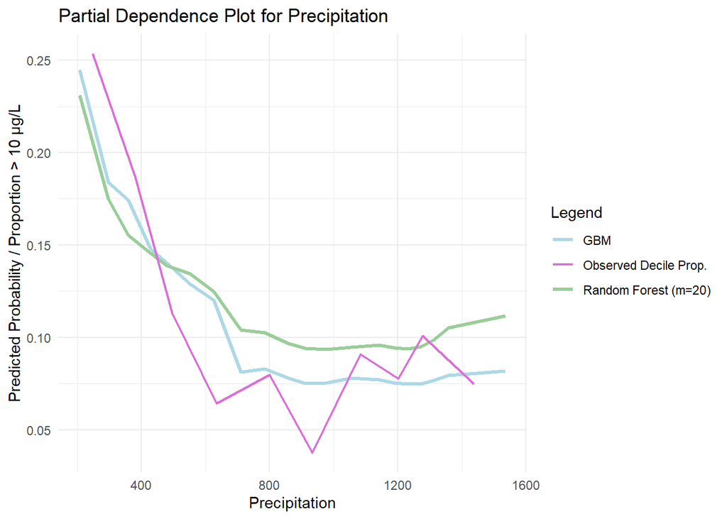

```r
# GBM partial dependence curve
pdp_gbm <- pdp_curve(
  \(nd) predict(gbm10, nd, n.trees = 4500, type = "response"),
  pdp_sample,
  "DMppt8110"
) %>%
  mutate(model = "GBM")

# random forest partial dependence curve
pdp_rf <- pdp_curve(
  \(nd) predict(rf20, nd, type = "prob")$.pred_yes,
  pdp_sample,
  "DMppt8110"
) %>%
  mutate(model = "Random Forest (m=20)")

# combine curves
pdp_models <- bind_rows(pdp_gbm, pdp_rf)

#  mean precipitation and observed proportion of positive outcomes
decile_data <- train %>%
  filter(!is.na(DMppt8110), !is.na(as10)) %>%
  mutate(decile = ntile(DMppt8110, 10)) %>%
  group_by(decile) %>%
  summarise(
    value = mean(DMppt8110),
    yhat = mean(as10 == "yes"),
    model = "Observed Decile Prop.",
    .groups = "drop"
  )

# plot
ggplot() +
  # Model Partial Dependence Lines
  geom_line(
    data = pdp_models,
    aes(x = value, y = yhat, color = model),
    linewidth = 1.1, linetype = "solid"
  ) +
  geom_line(
    data = decile_data,
    aes(x = value, y = yhat, color = model),
    linetype = "solid",
    linewidth = 0.8
  ) +
  scale_color_manual(
    name = "Legend",
    values = c(
      "GBM" = "lightblue",
      "Random Forest (m=20)" = "darkseagreen3",
      "Observed Decile Prop." = "orchid"
    )
  ) +
  labs(
    x = "Precipitation",
    y = "Predicted Probability / Proportion > 10 µg/L",
    title = "Partial Dependence Plot for Precipitation",
    color = "Legend",
    linetype = "Legend"
  ) +
  theme_minimal()
```

14. Using the random forest’s **OOB** predicted probabilities (no test data), plot sensitivity, specificity and PPV against the cutoff with `probably::threshold_perf()`. Pick the cutoff that maximises Youden’s J. Apply it to the test set and report sensitivity, specificity, PPV and the share of wells flagged.

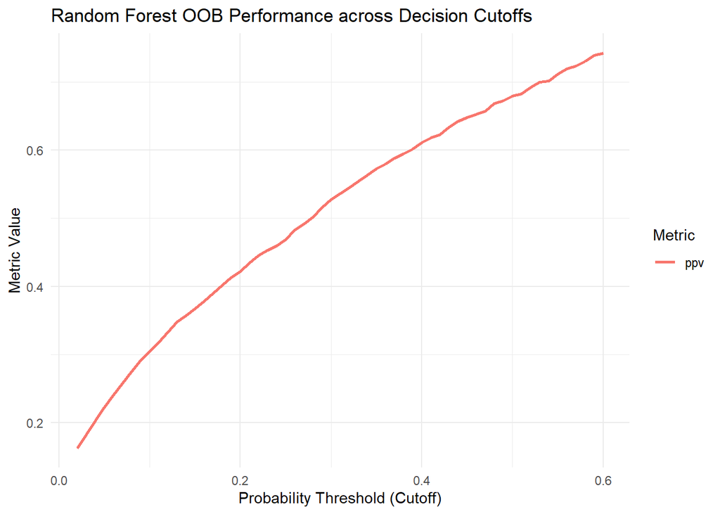

```r
# oob_df <- tibble(truth = train$as10, .pred_yes = oob_prob) |>
  # threshold_perf(truth, .pred_yes, thresholds = seq(0.02, 0.6, by = 0.01),
               # metrics = metric_set(sensitivity, specificity, j_index, ppv))

oob_prob <- extract_fit_engine(rf20)$predictions[, "yes"]

oob_df <- tibble(
  truth    = train$as10,
  .pred_yes = oob_prob
)

thresh_perf <- oob_df |>
  threshold_perf(
    truth,
    .pred_yes,
    thresholds = seq(0.02, 0.6, by = 0.01),
    metrics    = metric_set(sensitivity, specificity, j_index, ppv)
  )

# calculate sensitivity and specificity
thresh_perf %>%
  filter(.metric %in% c("sens", "spec", "ppv")) %>%
  ggplot(aes(x = .threshold, y = .estimate, color = .metric)) +
  geom_line(linewidth = 1) +
  labs(
    x = "Probability Threshold (Cutoff)",
    y = "Metric Value",
    title = "Random Forest OOB Performance across Decision Cutoffs",
    color = "Metric"
  ) +
  theme_minimal()
```

```r
# find cutoff value
best_cutoff_row <- thresh_perf %>%
  filter(.metric == "j_index") %>%
  slice_max(.estimate, n = 1, with_ties = FALSE)

best_cutoff <- best_cutoff_row$.threshold
print(best_cutoff)
```

```
## [1] 0.13
```

```r
# apply best cutoff to metrics
# predict test set probabilities using rf20
test_prob_rf20 <- predict(rf20, new_data = test, type = "prob")$.pred_yes

test_perf_optimal <- test_metrics(
  truth = test$as10,
  prob_yes = test_prob_rf20,
  cut = best_cutoff
) %>%
  mutate(
    cutoff = best_cutoff,
    share_flagged = mean(test_prob_rf20 > best_cutoff),
    .before = 1
  )

print(test_perf_optimal)
```

```
## # A tibble: 1 × 7
##   cutoff share_flagged accuracy sensitivity specificity   auc kappa
##    <dbl>         <dbl>    <dbl>       <dbl>       <dbl> <dbl> <dbl>
## 1   0.13         0.238    0.810       0.723       0.821 0.856 0.356
```

> **Q5.** Which predictors are important under all three measures, and where do the measures disagree? Why might impurity importance favour continuous variables over rare binary ones? Describe the precipitation partial dependence, and say whether it is a causal effect of precipitation. Is it relevant to your extreme-weather question? (Precipitation here is a 1981–2010 average.) If an epidemiologist used these predictions as the exposure in a study of arsenic and bladder cancer, would you give them the 0.5 class, your Youden class, or the probability, and why? Last, the paper’s test set is a random 30% of wells. What would a spatially blocked test set measure that this one does not?

Precipitation and soil horizon geochemistry variables are important under all three measures. Impurity importance may favor continuous variables over rare binary ones because there is more opportunity for splitting. The partial dependence plot for precipitation shows that there is a large influence of precipitation in the models, but it is unclear if it is a causal effect of precipitation. If an epidemiologist used these predictions as the exposure in a study of arsenic and bladder cancer, I would give them the probability. A spatially blocked test set would consider how far away training and testing well points are.

# 4 Starter code

```r
library(tidyverse)
library(tidymodels)
library(gbm)
library(rpart)
library(rpart.plot)
library(ranger)
library(xgboost)
library(probably)
tidymodels_prefer()

as_raw <- read_csv("AsModelInput.csv")
outcome_cols <- c("bas1", "bas5", "bas10", "As3Cat", "spl1", "spl5", "spl10", "spl3cat")
predictors   <- setdiff(names(as_raw), outcome_cols)          # 85 predictors

wells <- as_raw |>
  filter(if_all(all_of(predictors), \(x) !is.na(x))) |>      # drops 27 wells
  mutate(as10   = factor(if_else(bas10 == 1, "yes", "no"), levels = c("yes", "no")),
         As3Cat = factor(As3Cat))
train <- wells |> filter(spl10)
test  <- wells |> filter(!spl10)
f10   <- reformulate(predictors, response = "as10")

# ---- helper: the five Table 1 metrics at a probability cutoff ----------------
test_metrics <- function(truth, prob_yes, cut = 0.5) {
  cls <- factor(if_else(prob_yes > cut, "yes", "no"), levels = c("yes", "no"))
  tibble(accuracy    = accuracy_vec(truth, cls),
         sensitivity = sensitivity_vec(truth, cls),
         specificity = specificity_vec(truth, cls),
         auc         = roc_auc_vec(truth, prob_yes),
         kappa       = kap_vec(truth, cls))
}

# ---- Part A ------------------------------------------------------------------
set.seed(1234)
gbm10 <- gbm(reformulate(predictors, "bas10"), data = train,   # gbm wants a 0/1 outcome
             distribution = "bernoulli", n.trees = 4500, interaction.depth = 6,
             shrinkage = 0.01, n.minobsinnode = 10, bag.fraction = 0.5)   # ~2-4 min
p_gbm_test <- predict(gbm10, test, n.trees = 4500, type = "response")
test_metrics(test$as10, p_gbm_test)

logit10 <- logistic_reg() |> fit(f10, data = train)
p_logit_test <- predict(logit10, test, type = "prob")$.pred_yes

# ---- Part B ------------------------------------------------------------------
set.seed(1234)
tree_max <- rpart(f10, data = train, method = "class", parms = list(split = "gini"),
                  control = rpart.control(minsplit = 20, minbucket = 5, cp = 0, xval = 10))
printcp(tree_max); plotcp(tree_max)

set.seed(1234)
folds <- vfold_cv(train, v = 5, strata = as10)            # reuse these folds in Part D
cart_spec <- decision_tree(cost_complexity = tune(), min_n = 20) |>
  set_engine("rpart") |> set_mode("classification")
cart_res <- tune_grid(workflow(f10, cart_spec), resamples = folds,
                      grid = tibble(cost_complexity = 10^seq(-4, -1.5, by = 0.5)),
                      metrics = metric_set(accuracy, roc_auc))
select_by_one_std_err(cart_res, desc(cost_complexity), metric = "accuracy")
tree_small <- rpart::prune(tree_max, cp = 0.0065)   # rpart::, because another package also has a prune()
rpart.plot(tree_small, extra = 107)

# ---- Part C ------------------------------------------------------------------
# min_n = 1 grows full trees, as randomForest() does (slides 41, 52)
rf_fit <- function(mtry, trees = 500, data = train, formula = f10, ...) {
  rand_forest(mtry = mtry, trees = trees, min_n = 1) |>
    set_engine("ranger", seed = 1234, ...) |>
    set_mode("classification") |>
    fit(formula, data = data)
}
rf20 <- rf_fit(20)
extract_fit_engine(rf20)$prediction.error                 # OOB Brier score
oob_prob <- extract_fit_engine(rf20)$predictions[, "yes"] # OOB probability for every training well
roc_auc_vec(train$as10, oob_prob)                         # OOB AUC
# 3-class: rf_fit(20, data = train3, formula = reformulate(predictors, "As3Cat"))
#   with train3 <- wells |> filter(!is.na(As3Cat), spl3cat)

# ---- Part D ------------------------------------------------------------------
xgb_spec <- boost_tree(trees = tune(), tree_depth = tune(), learn_rate = tune(),
                       min_n = 10, sample_size = 0.5) |>
  set_engine("xgboost") |> set_mode("classification")
xgb_grid <- expand_grid(trees = c(250, 500, 1000, 2000, 3000),
                        tree_depth = c(1, 3, 6), learn_rate = c(0.01, 0.1))
xgb_res <- tune_grid(workflow(f10, xgb_spec), resamples = folds, grid = xgb_grid,
                     metrics = metric_set(roc_auc, accuracy))     # ~2-5 min
xgb_final <- finalize_workflow(workflow(f10, xgb_spec), select_best(xgb_res, metric = "roc_auc")) |>
  last_fit(split = make_splits(train, test))
p_xgb_test <- collect_predictions(xgb_final)$.pred_yes

# ---- Part E ------------------------------------------------------------------
summary(gbm10, plotit = FALSE)                                    # relative influence
rf_perm <- rf_fit(20, importance = "permutation")
extract_fit_engine(rf_perm)$variable.importance

# partial dependence: average prediction when every well is set to each grid value (L11 slide 9)
pdp_curve <- function(pred_fun, data, var,
                      grid = quantile(data[[var]], seq(0.02, 0.98, length.out = 20))) {
  map_dfr(grid, \(v) tibble(value = v, yhat = mean(pred_fun(mutate(data, !!var := v)))))
}
set.seed(1)
pdp_sample <- slice_sample(train, n = 2000)          # 2,000 wells is plenty and much faster
pdp_curve(\(nd) predict(gbm10, nd, n.trees = 4500, type = "response"), pdp_sample, "DMppt8110")
pdp_curve(\(nd) predict(rf20, nd, type = "prob")$.pred_yes,           pdp_sample, "DMppt8110")

tibble(truth = train$as10, .pred_yes = oob_prob) |>
  threshold_perf(truth, .pred_yes, thresholds = seq(0.02, 0.6, by = 0.01),
                 metrics = metric_set(sensitivity, specificity, j_index, ppv))
```

# 5 Check your numbers